# Bud segmentation of mRNAs

Edward Wallace

2026-07-13

# Summary

Analysis of CLB2 + ASH1, SUN4, SRL1, mRNAs by smFISH including bud segmentation. Population-level cell analysis in R started by EW on 8 July 2026, continued through 13 July 2026.

Goal is to produce figures summarising the dataset:

- abundance and bud localization of mRNAs in wild-type
- comparative bud localization in different strains
- whatever cell statistics we need to support these arguments.

# Load bud segmentation data

Define pixel dimensions in micrometres (um), 0.065 micron per pixel for the 100x objective.

Also set range of sizes to plot for total cell area, bud area, nuclear area, axis limits, in micrometres.

```r
pixel_width <- 0.065
pixel_area  <- pixel_width^2

cell_area_limits <- c(6, 30)
bud_area_limits  <- c(0, 15)
nuc_area_limits  <- c(0, 3.5)

cell_length_limits <- c(2, 20)
```

```r
# make short table here of strain ids and names in desired order
strain_table <-
  tribble(~strain, ~condition, ~strain_nice,
    "YET915", "WT",    "WT",
    "YET916", "ΔSSD1", "ssd1Δ",
    "YET919", "ΔMPT5", "mpt5∆",
    "YET563", "ΔSHE2", "she2∆",
    "YET572", "ΔSHE3", "she3∆",
    "YET918", "ΔSUN4", "sun4∆",
    "YET921", "ΔSEC72","sec72∆"
    ) %>%
  mutate(strain_nice = as_factor(strain_nice))

strain_table
```

```
## # A tibble: 7 × 3
##   strain condition strain_nice
##   <chr>  <chr>     <fct>
## 1 YET915 WT        WT
## 2 YET916 ΔSSD1     ssd1Δ
## 3 YET919 ΔMPT5     mpt5∆
## 4 YET563 ΔSHE2     she2∆
## 5 YET572 ΔSHE3     she3∆
## 6 YET918 ΔSUN4     sun4∆
## 7 YET921 ΔSEC72    sec72∆
```

```r
mrna_names <- c("CLB2 + ASH1", "SRL1", "SUN4")

mrna_names
```

```
## [1] "CLB2 + ASH1" "SRL1"        "SUN4"
```

```r
mrna_colour_values <- c("CLB2 + ASH1" = "magenta3",
               "SRL1" = "goldenrod3",
               "SUN4" = "forestgreen")

scale_colour_mrna <- function(...) {
  scale_colour_manual(
    values = mrna_colour_values,
    ...)
}

scale_fill_mrna <- function(...) {
  scale_fill_manual(
    values = mrna_colour_values,
    ...)
}
```

```r
mrna_alldata <- here::here("data", "Mara_budSegmentationData20260311.csv") %>%
  read_csv() %>%
  select(!starts_with("Unnamed") ) %>%
  select(!"condition + strain") %>%
  rename(row_id = "...1") %>%
  mutate(replicate =
           factor(replicate,
                  levels = c("BR1", "BR2", "BR3", "BR4", "BR5")),
         mRNA = factor(mRNA,
                       levels = c("ASH1CLB2", "SRL1", "SUN4"),
                       labels = c("CLB2 + ASH1", "SRL1", "SUN4"), ),
         area_umsq     = area * pixel_area,
         area_bud_umsq = area_bud * pixel_area,
         axis_minor_length_um = axis_minor_length * pixel_width,
         axis_major_length_um = axis_major_length * pixel_width,
         ) %>%
  rename_with(str_replace_all, pattern = "-", replacement = "_") %>%
  left_join(strain_table, by = c("strain", "condition"))
```

```
## ──────────────────────────────────────────────────────── Delimiter: "," chr
## (8): source_folder, strain, replicate, mRNA, condition, condition + str... dbl
## (46): ...1, Unnamed: 0.1, Unnamed: 0, image_cell_id, bbox-0, bbox-1, bbo...
```

```r
mrna_alldata
```

```
## # A tibble: 37,578 × 56
##    row_id image_cell_id bbox_0 bbox_1 bbox_2 bbox_3  area eccentricity
##     <dbl>         <dbl>  <dbl>  <dbl>  <dbl>  <dbl> <dbl>        <dbl>
##  1      0             8      2    550     76    624  3714        0.694
##  2      1            10     16     32     97    170  5918        0.941
##  3      2            12     18   1011     73   1074  2750        0.427
##  4      3            13     21    252     81    322  3260        0.556
##  5      4            16     21    375    115    564  9487        0.953
##  6      5            21     67   1946    141   2018  4010        0.491
##  7      6            23     72    193    133    257  2969        0.265
##  8      7            24     73   1123    181   1201  5039        0.708
##  9      8            26     80    290    147    378  4487        0.665
## 10      9            27     92     33    166    108  4032        0.655
## # ℹ 37,568 more rows
## # ℹ 48 more variables: axis_minor_length <dbl>, axis_major_length <dbl>,
## #   orientation <dbl>, perimeter <dbl>, solidity <dbl>, bbox_0_bud <dbl>,
## #   bbox_1_bud <dbl>, bbox_2_bud <dbl>, bbox_3_bud <dbl>, area_bud <dbl>,
## #   eccentricity_bud <dbl>, axis_minor_length_bud <dbl>,
## #   axis_major_length_bud <dbl>, orientation_bud <dbl>, perimeter_bud <dbl>,
## #   solidity_bud <dbl>, spots <dbl>, dense_regions <dbl>, …
```

## Count assigned cells

```r
mrna_alldata %>%
  filter(mRNA == "SRL1") %>%
  group_by(strain_nice, replicate) %>%
  count() %>%
  print(n = 30)
```

```
## # A tibble: 27 × 3
## # Groups:   strain_nice, replicate [27]
##    strain_nice replicate     n
##    <fct>       <fct>     <int>
##  1 WT          BR1         209
##  2 WT          BR2         729
##  3 WT          BR3         444
##  4 WT          BR4         183
##  5 WT          BR5         329
##  6 ssd1Δ       BR1         383
##  7 ssd1Δ       BR2         228
##  8 ssd1Δ       BR3         275
##  9 ssd1Δ       BR4        1289
## 10 mpt5∆       BR1         418
## 11 mpt5∆       BR2         294
```

[output cut: 16 more lines]

## Count assigned cells w/ no RNA detected

```r
mrna_alldata %>%
  group_by(strain_nice, replicate) %>%
  summarise(total_all_RNAs = sum(total_RNAs)) %>%
  count() %>%
  print(n = 30)
```

```
## # A tibble: 7 × 2
## # Groups:   strain_nice [7]
##   strain_nice     n
##   <fct>       <int>
## 1 WT              5
## 2 ssd1Δ           4
## 3 mpt5∆           3
## 4 she2∆           3
## 5 she3∆           5
## 6 sun4∆           3
## 7 sec72∆          4
```

# Overview plots across strains

## mRNAs per cell

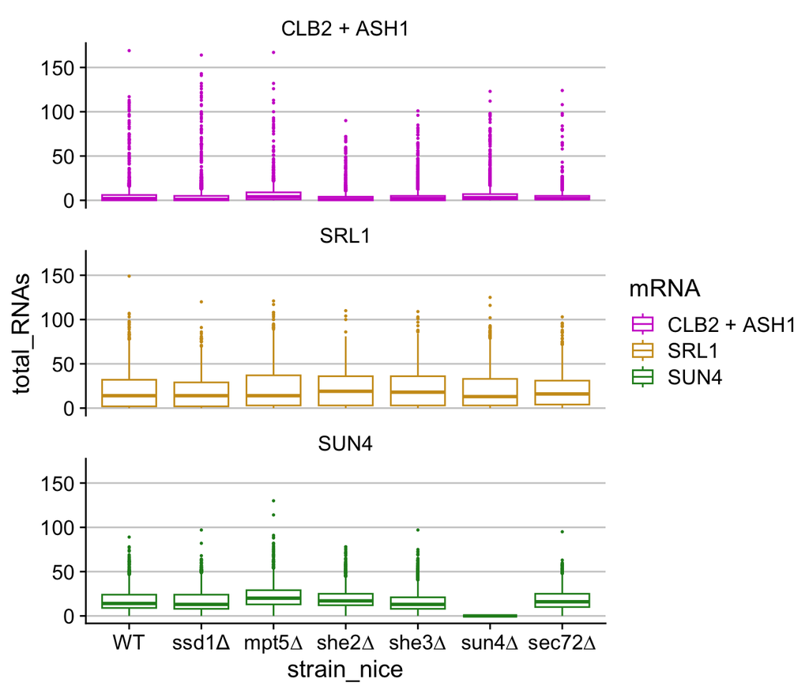

```r
ggplot(data = mrna_alldata) +
  geom_boxplot(aes(x = strain_nice, colour = mRNA, y = total_RNAs),
               outlier.size = 0.3) +
  facet_wrap(~ mRNA,
             ncol = 1) +
  theme(panel.grid.major.y = element_line(colour = "grey80")) +
  scale_colour_mrna()
```

## mRNAs per mother

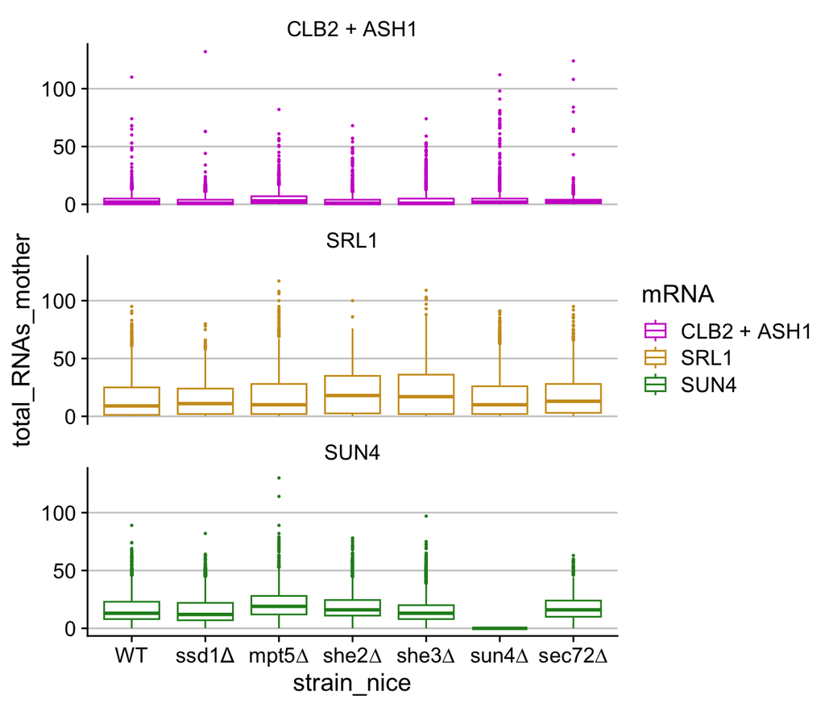

```r
ggplot(data = mrna_alldata, aes(x = strain_nice, colour = mRNA)) +
  geom_boxplot(aes(y = total_RNAs_mother),
               outlier.size = 0.3) +
  facet_wrap(~ mRNA,
             ncol = 1) +
  theme(panel.grid.major.y = element_line(colour = "grey80")) +
  scale_colour_mrna()
```

## mRNAs per bud, filtering only for budded cells

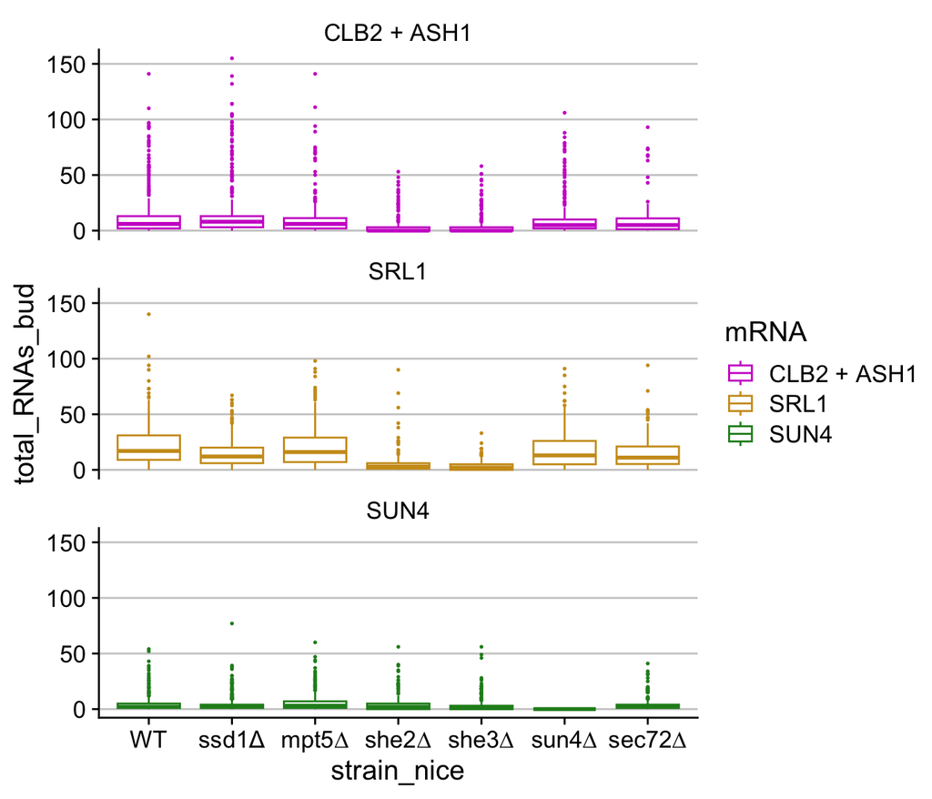

```r
ggplot(data = mrna_alldata %>%
         filter(area_bud > 0),
       aes(x = strain_nice, colour = mRNA)) +
  geom_boxplot(aes(y = total_RNAs_bud),
               outlier.size = 0.3) +
  facet_wrap(~ mRNA,
             ncol = 1) +
  theme(panel.grid.major.y = element_line(colour = "grey80")) +
  scale_colour_mrna()
```

## Count vs total cell area for WT

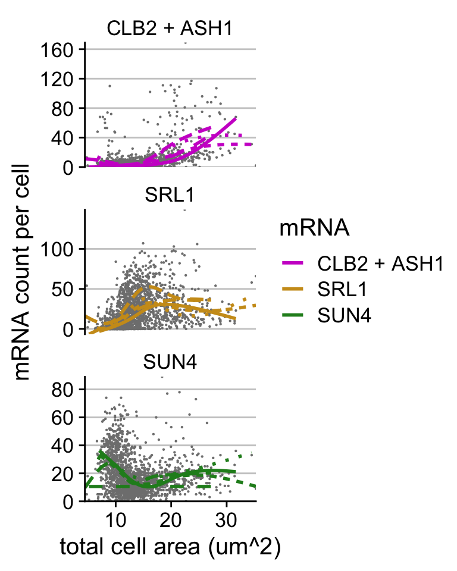

```r
plot_count_vs_area_WT <-
  ggplot(data = mrna_alldata %>%
           filter(area_umsq > 4,
                  strain_nice %in% c("WT")),
         aes(x = area_umsq, y = total_RNAs)) +
  geom_point(size = 0.1, colour = "grey50") +
  geom_smooth(aes(linetype = replicate, colour = mRNA),
              method = "gam", se = FALSE) +
  facet_wrap(~ mRNA, ncol = 1, scales = "free_y") +
  coord_cartesian(expand = FALSE) +
  scale_colour_mrna() +
  theme(panel.grid.major.y = element_line(colour = "grey80")) +
  labs(x = "total cell area (um^2)",
       y = "mRNA count per cell") +
  guides(colour = guide_legend(order = 1),
         linetype = "none")

plot_count_vs_area_WT
```

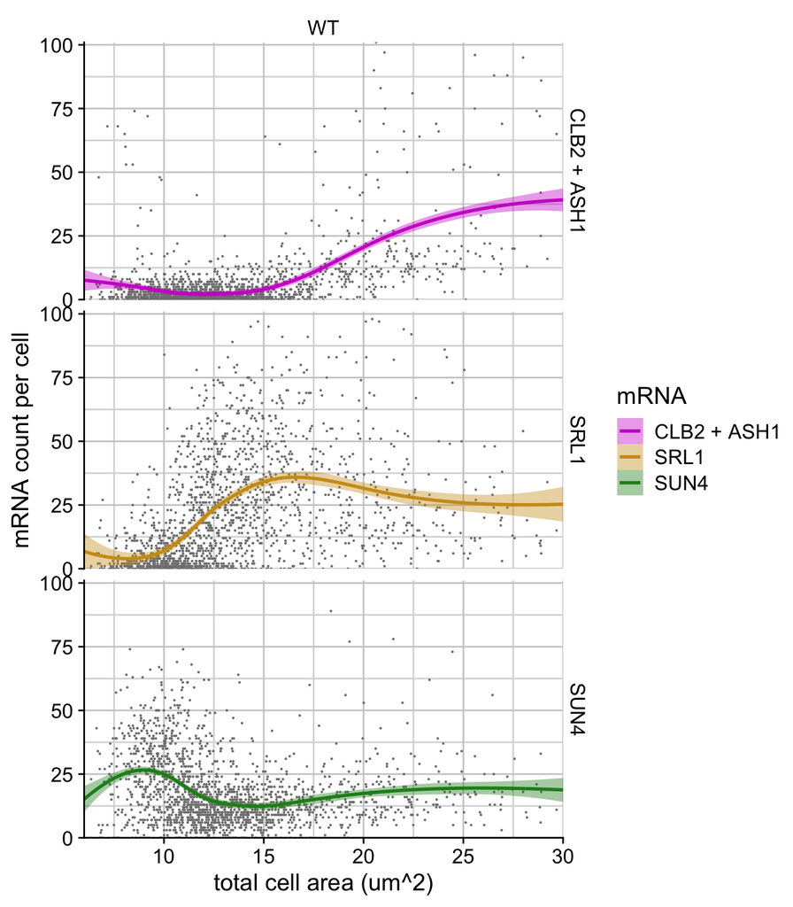

```r
ggplot(data = mrna_alldata %>%
           filter(
             area_umsq > 4,
             strain_nice %in% c("WT")
           ),
         aes(x = area_umsq, y = total_RNAs)) +
  geom_point(size = 0.1, colour = "grey50") +
  geom_smooth(aes(colour = mRNA, fill = mRNA),
              method = "gam",  se = TRUE) +
  facet_grid(mRNA ~ strain_nice, scales = "free_y") +
  theme(panel.grid.major.x = element_line(colour = "grey80"),
        panel.grid.major.y = element_line(colour = "grey80"),
        panel.grid.minor.x = element_line(colour = "grey85"),
        panel.grid.minor.y = element_line(colour = "grey85"),
        ) +
  coord_cartesian(xlim = cell_area_limits, ylim = c(0,101),
                  expand = FALSE) +
  scale_colour_mrna() + scale_fill_mrna() +
  labs(x = "total cell area (um^2)",
       y = "mRNA count per cell")
```

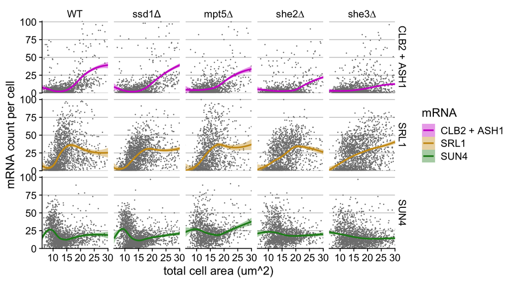

```r
plot_countvsarea_vsstrain <-
  ggplot(data = mrna_alldata %>%
           filter(
             area_umsq > 4,
             strain_nice %in% c("WT", "ssd1Δ", "mpt5∆", "she2∆", "she3∆")
           ),
         aes(x = area_umsq, y = total_RNAs)) +
  geom_point(size = 0.1, colour = "grey50") +
  geom_smooth(aes(colour = mRNA, fill = mRNA),
              method = "gam",  se = TRUE) +
  facet_grid(mRNA ~ strain_nice, scales = "free_y") +
  theme(panel.grid.major.y = element_line(colour = "grey80")) +
  coord_cartesian(xlim = cell_area_limits, ylim = c(0,101),
                  expand = FALSE) +
  scale_colour_mrna() + scale_fill_mrna() +
  labs(x = "total cell area (um^2)",
       y = "mRNA count per cell")

plot_countvsarea_vsstrain
```

## Count vs bud area for WT

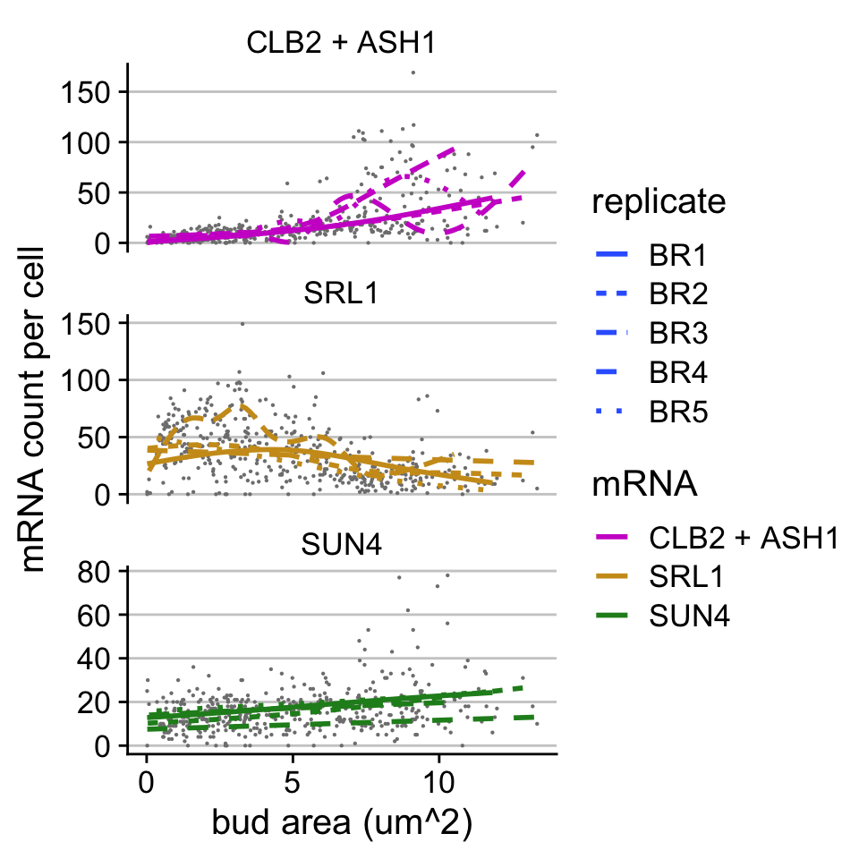

```r
ggplot(data = mrna_alldata %>%
         filter(area_bud > 0,
                strain_nice %in% c("WT")),
       aes(x = area_bud_umsq, y = total_RNAs)) +
  geom_point(size = 0.1, colour = "grey50") +
  geom_smooth(aes(linetype = replicate, colour = mRNA),
              method = "gam", se = FALSE) +
  facet_wrap(~ mRNA, ncol = 1, scales = "free_y") +
  scale_colour_mrna()  +
  theme(panel.grid.major.y = element_line(colour = "grey80")) +
  labs(x = "bud area (um^2)",
       y = "mRNA count per cell")
```

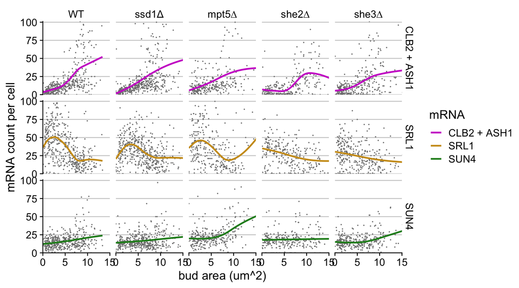

```r
ggplot(data = mrna_alldata %>%
         filter(
           area_bud > 0,
           strain_nice %in% c("WT", "ssd1Δ", "mpt5∆", "she2∆", "she3∆")
           ),
       aes(x = area_bud_umsq, y = total_RNAs)) +
  geom_point(size = 0.1, colour = "grey50") +
  geom_smooth(aes(colour = mRNA),
              method = "gam",  se = FALSE) +
  facet_grid(mRNA ~ strain_nice, scales = "free_y") +
  theme(panel.grid.major.y = element_line(colour = "grey80")) +
  coord_cartesian(xlim = bud_area_limits, ylim = c(0,101),
                  expand = FALSE) +
  scale_colour_mrna() +
  labs(x = "bud area (um^2)",
       y = "mRNA count per cell")
```

## Proportion in bud, filtering only for budded cells

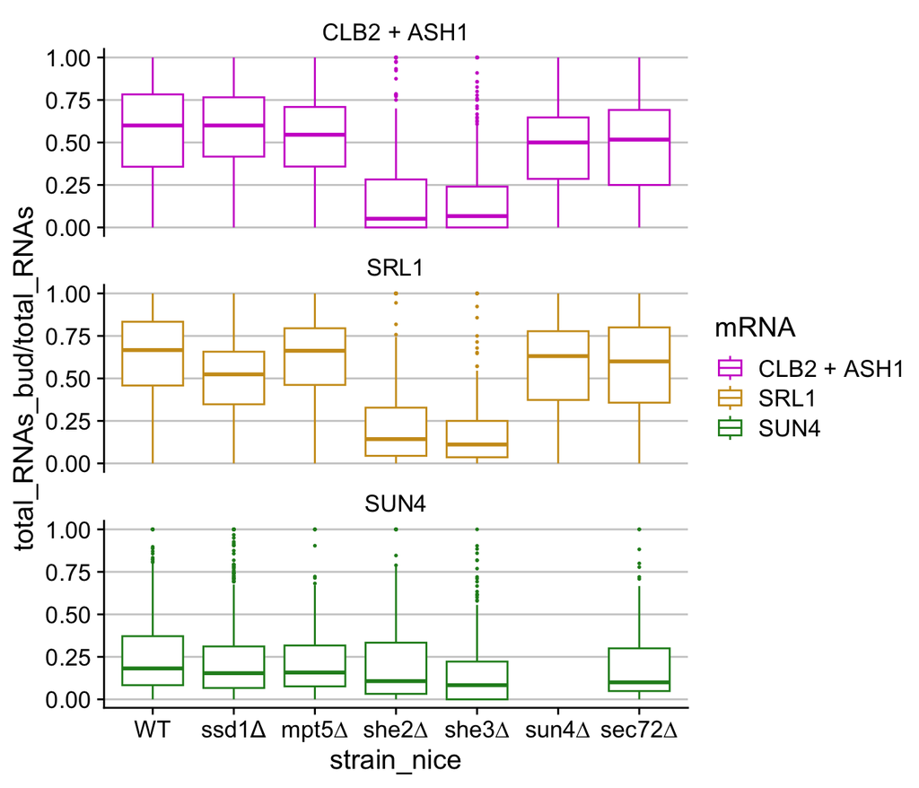

```r
ggplot(data = mrna_alldata %>%
         filter(area_bud > 0),
       aes(x = strain_nice, colour = mRNA)) +
  geom_boxplot(aes(y = total_RNAs_bud / total_RNAs),
               outlier.size = 0.3) +
  facet_wrap(~ mRNA,
             ncol = 1) +
  theme(panel.grid.major.y = element_line(colour = "grey80")) +
  scale_y_continuous(limits = c(0,1)) +
  scale_colour_mrna()
```

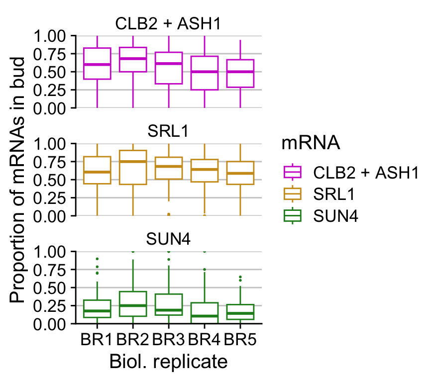

```r
plot_propinbud_wtreplicates <-
  ggplot(data = mrna_alldata %>%
           filter(area_bud > 0,
                  strain_nice %in% c("WT")),
         aes(x = replicate, colour = mRNA)) +
  geom_boxplot(aes(y = total_RNAs_bud / total_RNAs),
               outlier.size = 0.3,
               position = position_dodge(preserve = "single")) +
  facet_wrap(~ mRNA,
             ncol = 1) +
  theme(panel.grid.major.y = element_line(colour = "grey80")) +
  scale_y_continuous("Proportion of mRNAs in bud",
                     limits = c(0,1), expand= c(0,0)) +
  scale_colour_mrna() +
  labs(x = "Biol. replicate")

plot_propinbud_wtreplicates
```

```r
ggsave(here::here("figure","plot_propinbud_wtreplicates.pdf"),
       width = unit(4.5, "in"), height = unit(4, "in") )
```

## Proportion in bud, across biological replicates, for most relevant strains

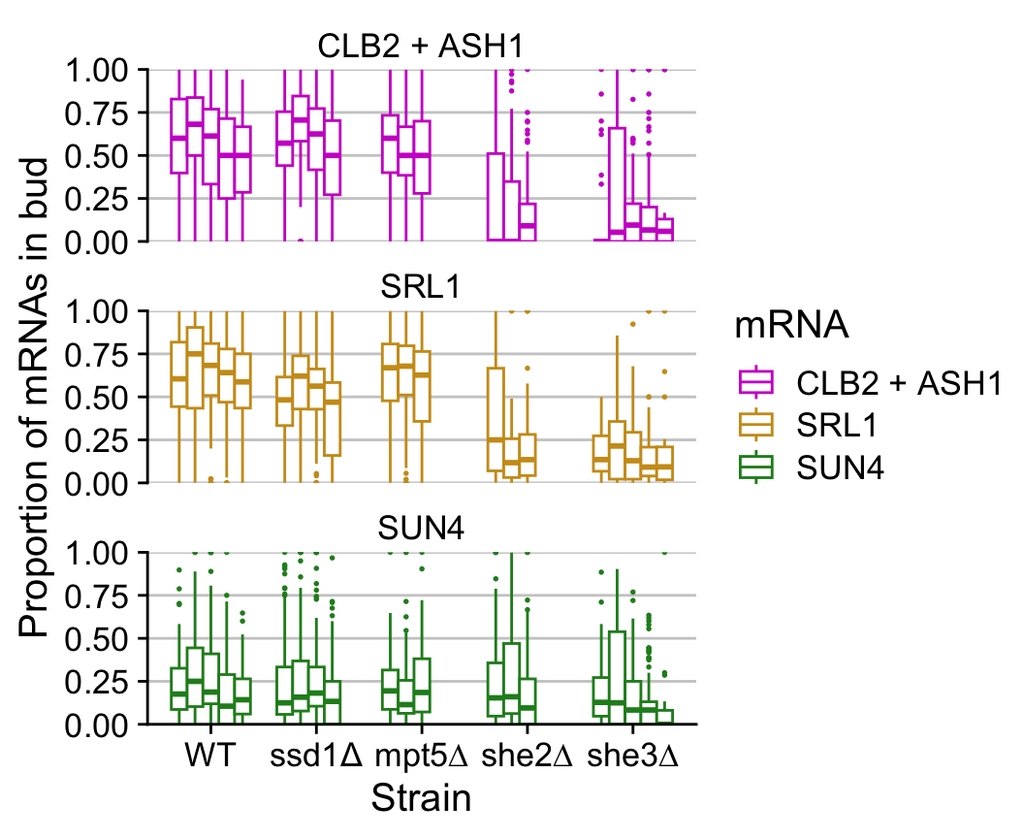

```r
plot_propinbud_replicates <-
  ggplot(data = mrna_alldata %>%
           filter(area_bud > 0,
                  strain_nice %in% c("WT", "ssd1Δ", "mpt5∆", "she2∆", "she3∆")),
         aes(x = strain_nice, colour = mRNA)) +
  geom_boxplot(aes(y = total_RNAs_bud / total_RNAs,
                   group = interaction(strain_nice, replicate)),
               outlier.size = 0.3,
               position = position_dodge(preserve = "single")) +
  facet_wrap(~ mRNA,
             ncol = 1) +
  theme(panel.grid.major.y = element_line(colour = "grey80")) +
  scale_y_continuous("Proportion of mRNAs in bud",
                     limits = c(0,1), expand= c(0,0)) +
  scale_colour_mrna() +
  labs(x = "Strain")

plot_propinbud_replicates
```

## Prop in bud vs bud size for WT

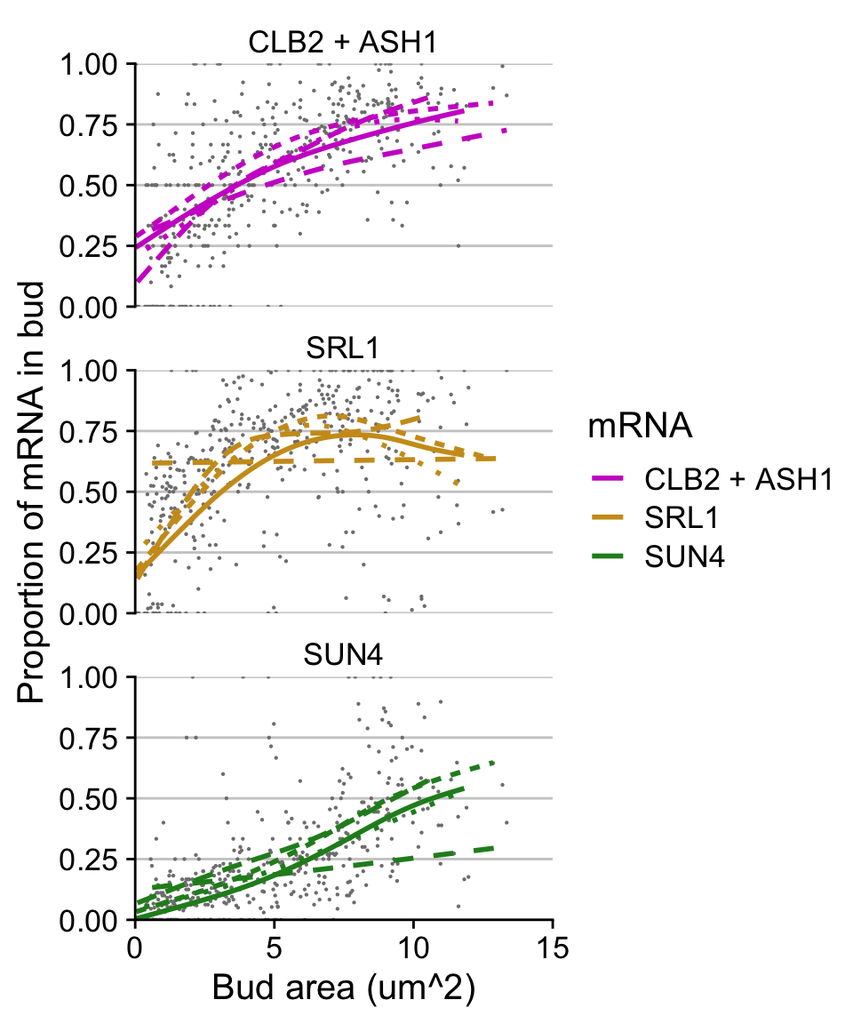

```r
plot_prop_vs_budarea_WT <-
ggplot(data = mrna_alldata %>%
         filter(strain_nice %in% c("WT"),
                area_bud > 0),
       aes(x = area_bud_umsq, y = total_RNAs_bud / total_RNAs)) +
  geom_point(size = 0.1, colour = "grey50") +
  geom_smooth(aes(linetype = replicate, colour = mRNA),
              method = "gam", se = FALSE) +
  facet_wrap(~ mRNA, ncol = 1, scales = "free_y") +
  theme(panel.grid.major.y = element_line(colour = "grey80")) +
  scale_y_continuous("Proportion of mRNA in bud",
                     limits = c(0,1)) +
  labs(x = "Bud area (um^2)") +
  coord_cartesian(xlim = bud_area_limits, expand = FALSE) +
  scale_colour_mrna() +
  guides(colour = guide_legend(order = 1),
         linetype = "none")

plot_prop_vs_budarea_WT
```

## Prop in bud vs bud size for relevant strains

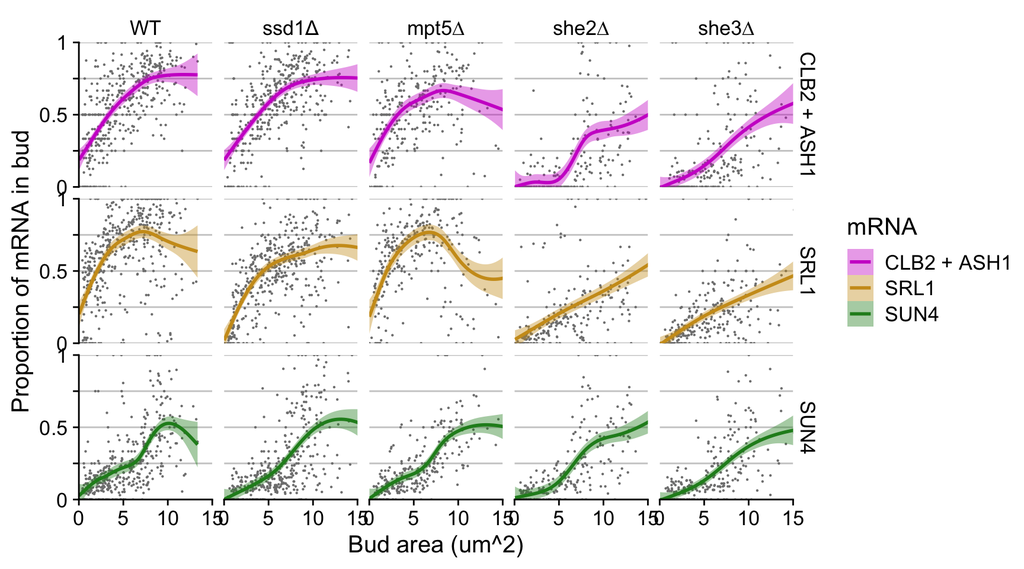

```r
ggplot(data = mrna_alldata %>%
         filter(strain_nice %in% c("WT", "ssd1Δ", "mpt5∆", "she2∆", "she3∆"),
                area_bud > 0,
                total_RNAs > 0),
       aes(x = area_bud_umsq, y = total_RNAs_bud / total_RNAs)) +
  geom_point(size = 0.1, colour = "grey50") +
  geom_smooth(aes(colour = mRNA, fill = mRNA),
              method = "gam",  se = TRUE) +
  facet_grid(mRNA ~ strain_nice) +
  theme(panel.grid.major.y = element_line(colour = "grey80")) +
  scale_y_continuous("Proportion of mRNA in bud",
                     limits = c(0,1),
                     breaks = c(0, 0.25, 0.5, 0.75, 1),
                     labels = c("0", "", "0.5", "", "1"),
                     oob = scales::squish) +
  labs(x = "Bud area (um^2)") +
  coord_cartesian(xlim = bud_area_limits, expand = FALSE) +
  scale_colour_mrna()  + scale_fill_mrna()
```

## Prop in bud vs prop of cell *area* in bud for relevant strains

This is good. It might make even more sense to have proportion of *volume* not area.

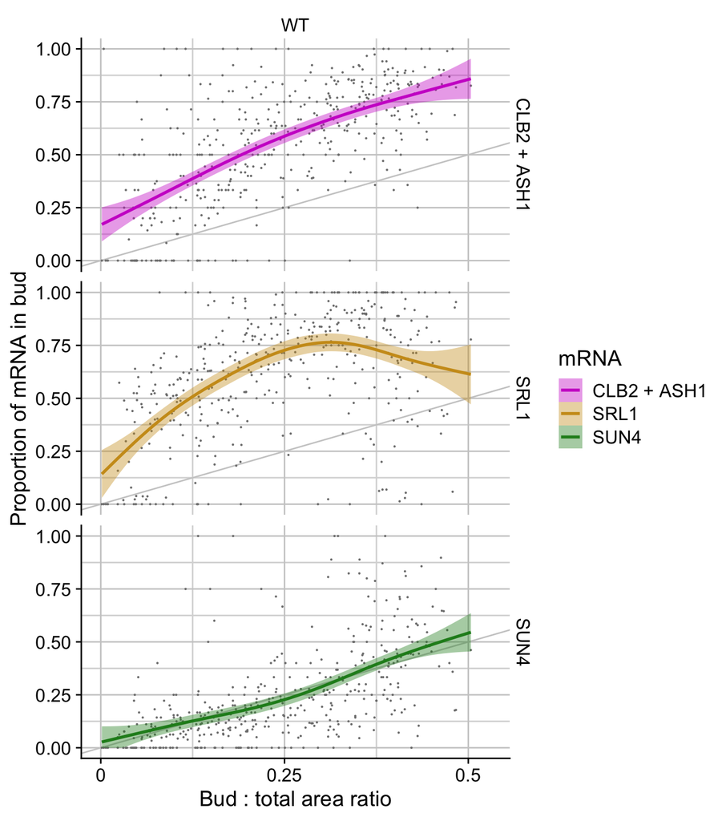

```r
ggplot(data = mrna_alldata %>%
         filter(strain_nice %in% c("WT"),
                area_bud > 0,
                total_RNAs > 0),
       aes(x = area_bud / area, y = total_RNAs_bud / total_RNAs)) +
  geom_abline(slope = 1, intercept = 0, colour = "grey80") +
  geom_point(size = 0.1, colour = "grey50") +
  geom_smooth(aes(colour = mRNA, fill = mRNA),
              method = "gam",  se = TRUE) +
  facet_grid(mRNA ~ strain_nice) +
  theme(panel.grid.major.x = element_line(colour = "grey80"),
        panel.grid.major.y = element_line(colour = "grey80"),
        panel.grid.minor.x = element_line(colour = "grey85"),
        panel.grid.minor.y = element_line(colour = "grey85"),
        ) +
  scale_y_continuous("Proportion of mRNA in bud",
                     limits = c(0,1),
                     breaks = c(0, 0.25, 0.5, 0.75, 1),
                     labels = c("0.00", "0.25", "0.50", "0.75", "1.00"),
                     oob = scales::squish) +
  scale_x_continuous("Bud : total area ratio",
                     limits = c(0,0.53),
                     breaks = c(0, 0.25, 0.5, 0.75, 1),
                     labels = c("0", "0.25", "0.5", "", "1")) +
  scale_colour_mrna() + scale_fill_mrna()
```

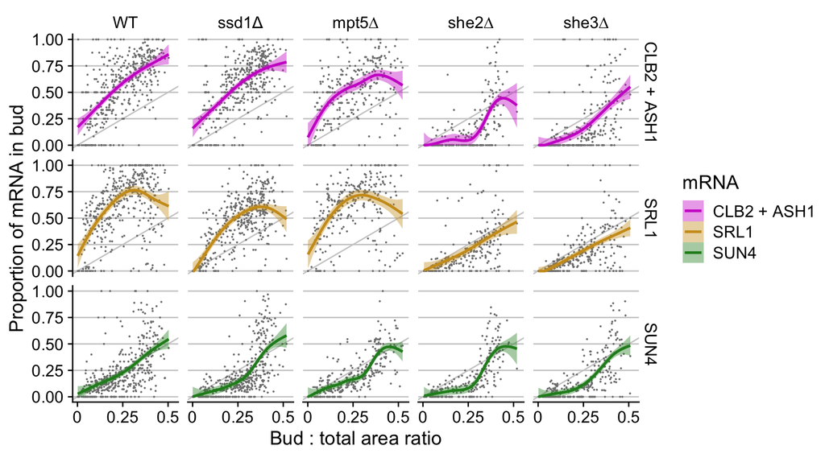

```r
plot_propinbud_vsareainbud <-
  ggplot(data = mrna_alldata %>%
         filter(strain_nice %in% c("WT", "ssd1Δ", "mpt5∆", "she2∆", "she3∆"),
                area_bud > 0,
                total_RNAs > 0),
       aes(x = area_bud / area, y = total_RNAs_bud / total_RNAs)) +
  geom_abline(slope = 1, intercept = 0, colour = "grey80") +
  geom_point(size = 0.1, colour = "grey50") +
  geom_smooth(aes(colour = mRNA, fill = mRNA),
              method = "gam",  se = TRUE) +
  facet_grid(mRNA ~ strain_nice) +
  theme(panel.grid.major.y = element_line(colour = "grey80")) +
  scale_y_continuous("Proportion of mRNA in bud",
                     limits = c(0,1),
                     breaks = c(0, 0.25, 0.5, 0.75, 1),
                     labels = c("0.00", "0.25", "0.50", "0.75", "1.00"),
                     oob = scales::squish) +
  scale_x_continuous("Bud : total area ratio",
                     limits = c(0,0.53),
                     breaks = c(0, 0.25, 0.5, 0.75, 1),
                     labels = c("0", "0.25", "0.5", "", "1")) +
  scale_colour_mrna() + scale_fill_mrna()

plot_propinbud_vsareainbud
```

## Print figure with mRNA count vs area and bud loc vs area ratio

```r
continuous_figure <-
  plot_grid(plot_countvsarea_vsstrain,
            plot_propinbud_vsareainbud,
            ncol = 1,
            align = "v",
            rel_heights = c(4.5,5),
            labels = "AUTO"
  )
ggsave(filename = here::here("figure","continuous_figure.pdf"),
       plot = continuous_figure,
       width = unit(9, "in"),
       height = unit(9.5, "in"),
       device=cairo_pdf )
```

## Distribution of cell area by strain

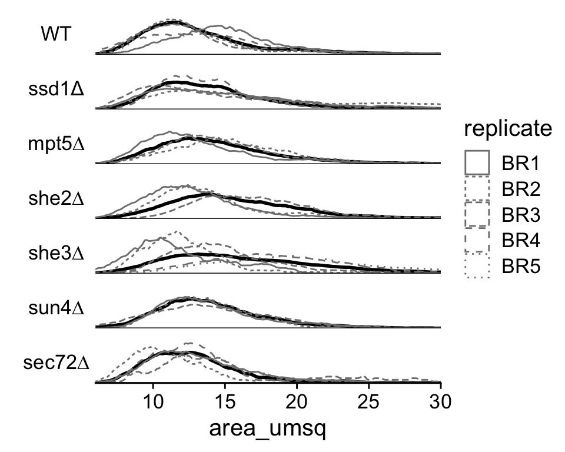

```r
ggplot(data = mrna_alldata,
       aes(x = area_umsq)) +
  geom_density(linewidth = 1,
              kernel = "rectangular") +
  geom_density(aes(linetype = replicate),
               colour = "grey50",
              kernel = "rectangular") +
  facet_wrap(~ strain_nice,
             ncol = 1,
        strip.position = "left") +
  geom_hline(yintercept = 0) +
  coord_cartesian(xlim = cell_area_limits, expand = FALSE) +
  theme(axis.text.y  = element_blank(),
        axis.ticks.y = element_blank(),
        axis.line.y  = element_blank(),
        axis.title.y = element_blank(),
        strip.text.y.left = element_text(angle = 0))
```

## Distribution of bud area by strain

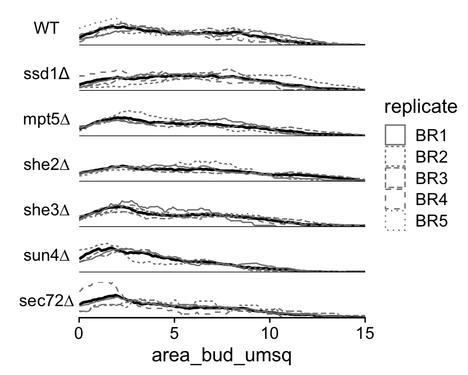

```r
ggplot(data = mrna_alldata %>%
         filter(area_bud_umsq > 0),
       aes(x = area_bud_umsq)) +
  geom_density(linewidth = 1,
              kernel = "rectangular") +
  geom_density(aes(linetype = replicate),
               colour = "grey50",
              kernel = "rectangular") +
  facet_wrap(~ strain_nice,
             ncol = 1,
        strip.position = "left") +
  geom_hline(yintercept = 0) +
  coord_cartesian(xlim = bud_area_limits, expand = FALSE) +
  theme(axis.text.y  = element_blank(),
        axis.ticks.y = element_blank(),
        axis.line.y  = element_blank(),
        axis.title.y = element_blank(),
        strip.text.y.left = element_text(angle = 0))
```

## Distribution of mother nuclear area by strain

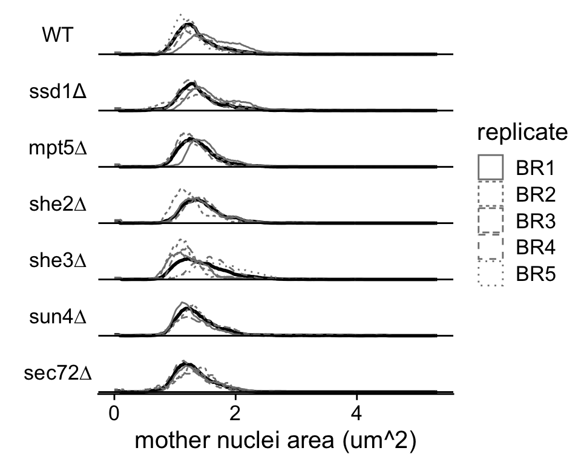

```r
ggplot(data = mrna_alldata ,
       aes(x = mother_nuclei_area * pixel_area)) +
  geom_density(linewidth = 1,
              kernel = "rectangular") +
  geom_density(aes(linetype = replicate),
               colour = "grey50",
              kernel = "rectangular") +
  facet_wrap(~ strain_nice,
             ncol = 1,
        strip.position = "left") +
  geom_hline(yintercept = 0) +
  # coord_cartesian(xlim = nuc_area_limits * pixel_area, expand = FALSE) +
  labs(x = "mother nuclei area (um^2)") +
  theme(axis.text.y  = element_blank(),
        axis.ticks.y = element_blank(),
        axis.line.y  = element_blank(),
        axis.title.y = element_blank(),
        strip.text.y.left = element_text(angle = 0))
```

## Distribution of bud nuclear area by strain

Looks terrible because most buds do not have nuclei.

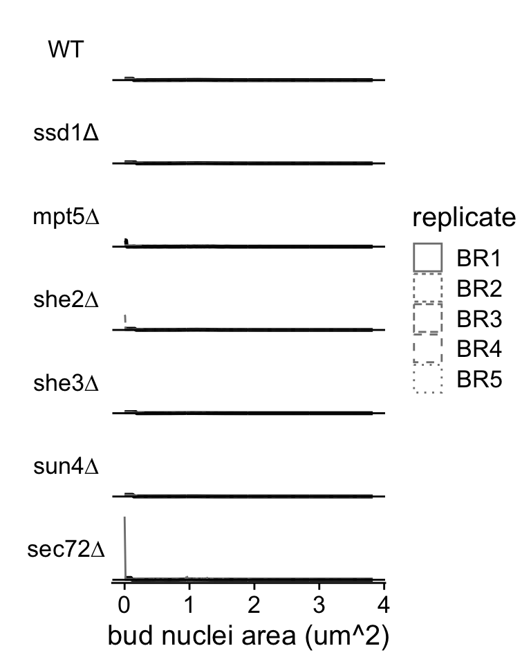

```r
ggplot(data = mrna_alldata %>%
         filter(area_bud > 0),
       aes(x = nuclei_bud_area * pixel_area)) +
  geom_density(linewidth = 1,
              kernel = "rectangular") +
  geom_density(aes(linetype = replicate),
               colour = "grey50",
              kernel = "rectangular") +
  facet_wrap(~ strain_nice,
             ncol = 1,
        strip.position = "left") +
  geom_hline(yintercept = 0) +
  #coord_cartesian(xlim = c(0,750), expand = FALSE) +
  labs(x = "bud nuclei area (um^2)") +
  theme(axis.text.y  = element_blank(),
        axis.ticks.y = element_blank(),
        axis.line.y  = element_blank(),
        axis.title.y = element_blank(),
        strip.text.y.left = element_text(angle = 0))
```

# Assign cell cycle phase based on cell statistics

The idea is:

Insisting on cells having the right number of nuclei should exclude cells that are not permeabilised, or that are otherwise strange and should not be counted.

We also did not use nuclear shape to assign morphology.

```r
# pick cells with <= 5 CLB2 + ASH1 mRNAs, for G1
uids_wfewCLB2ASH1 <-
    mrna_alldata %>%
  filter(mRNA == "CLB2 + ASH1",
         total_RNAs <= 5) %>%
  pull("uid")


mrna_alldata_wphase <-
  mrna_alldata %>%
  # filter for cells of sensible size - 2 um to 20 um
  filter(axis_major_length_um > cell_length_limits[1],
         axis_major_length_um < cell_length_limits[2]) %>%
  mutate(
    cell_cycle_phase =
      case_when(
        area_bud_umsq == 0 &
          mother_nuclei_count == 1 &
          uid %in% uids_wfewCLB2ASH1 ~
          "G1",
        area_bud_umsq > 0    &
          area_bud_umsq < 2  &
          mother_nuclei_count == 1 &
          nuclei_bud_count == 0 ~
          "S",
        area_bud_umsq >= 2 &
          area_bud_umsq < bud_area_limits[2] &
          mother_nuclei_count == 1 &
          nuclei_bud_count == 0 ~
          "G2",
        area_bud_umsq > 2  &
          mother_nuclei_count == 1 &
          nuclei_bud_count == 1 ~
          "M",
        .default = "NA"
      ) %>%
      factor(levels = c("G1", "S", "G2", "M"))
  )
```

We should check what the unassigned cells are doing - cells that are unreasonably small or have unreasonably large buds - but it is not a large proportion in wild-type.

## Check cell counts by phase across strains

```r
mrna_alldata_wphase %>%
  filter(mRNA == "SRL1") %>%
  group_by(strain_nice, cell_cycle_phase) %>%
  count() %>%
  print(n = 35)
```

```
## # A tibble: 35 × 3
## # Groups:   strain_nice, cell_cycle_phase [35]
##    strain_nice cell_cycle_phase     n
##    <fct>       <fct>            <int>
##  1 WT          G1                1266
##  2 WT          S                   95
##  3 WT          G2                 213
##  4 WT          M                  122
##  5 WT          <NA>               188
##  6 ssd1Δ       G1                1567
##  7 ssd1Δ       S                   73
##  8 ssd1Δ       G2                 235
##  9 ssd1Δ       M                  117
## 10 ssd1Δ       <NA>               173
## 11 mpt5∆       G1                 759
```

[output cut: 24 more lines]

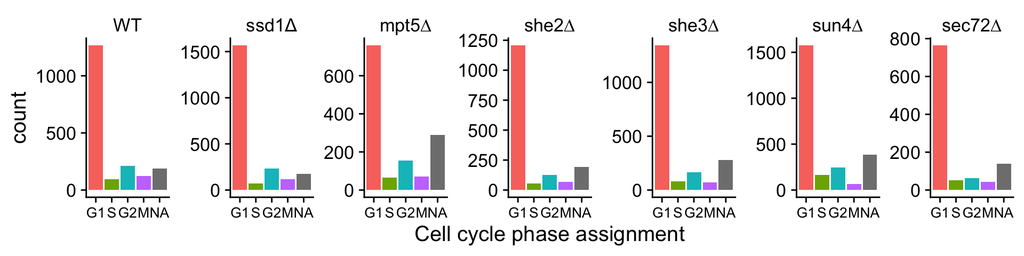

```r
ggplot(data = mrna_alldata_wphase %>%
         filter(mRNA == "SRL1")) +
  geom_bar(aes(x = cell_cycle_phase,
               fill = cell_cycle_phase)) +
  facet_wrap(~strain_nice, nrow = 1, scales = "free_y") +
  theme(legend.position = "none",
        axis.text.x = element_text(size = 10)) +
  labs(x = "Cell cycle phase assignment")
```

Something is different about *mpt5∆*.

### Check cell-level statistics for cell cycle phase.

Check distributions and correlations of:

- cell area in um^2, `area_umsq`
- cell length in um, `axis_major_length_um`
- bud area in um^2, `area_bud_umsq`
- bud length in um, `axis_major_length_bud_um`
- cell cycle phase assigned by rules, `cell_cycle_phase`

TO DO: Show NA cells in the boxplots here!

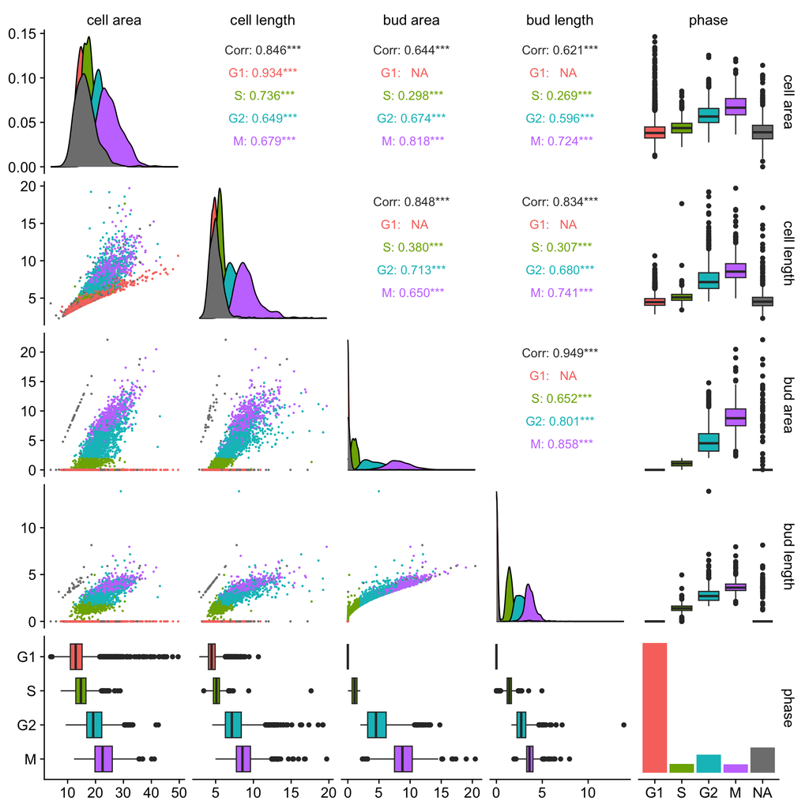

```r
mrna_alldata_wphase %>%
  filter(mRNA == "SUN4") %>%
  mutate(axis_major_length_bud_um =
           axis_major_length_bud * pixel_width ) %>%
  select("cell area"   = area_umsq,
         "cell length" = axis_major_length_um,
         "bud area"    = area_bud_umsq,
         "bud length"  = axis_major_length_bud_um,
         "phase"       = cell_cycle_phase) %>%
  # replace_na(list(phase = "N")) %>%
  ggpairs(aes(colour = phase),
          lower = list(continuous = wrap("points", size = 0.3),
                       combo = wrap("box_no_facet"),
                       discrete = "count") )
```

### For wild-type

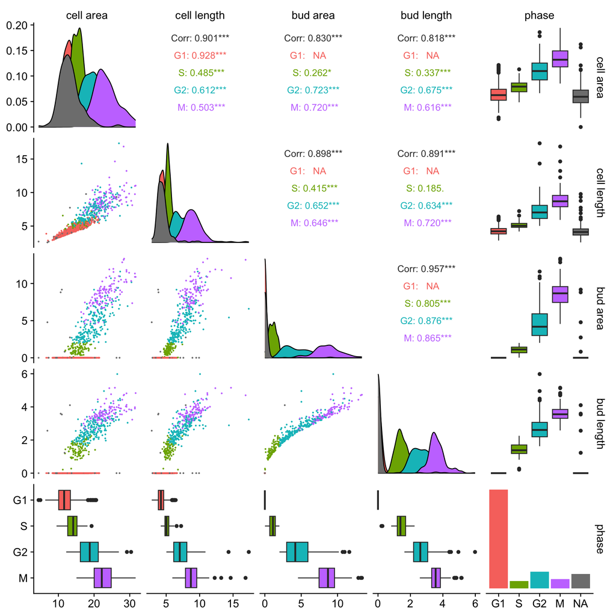

```r
mrna_alldata_wphase %>%
  filter(strain_nice == "WT", mRNA == "SUN4") %>%
  mutate(axis_major_length_bud_um =
           axis_major_length_bud * pixel_width ) %>%
  select("cell area"   = area_umsq,
         "cell length" = axis_major_length_um,
         "bud area"    = area_bud_umsq,
         "bud length"  = axis_major_length_bud_um,
         "phase"       = cell_cycle_phase) %>%
  ggpairs(aes(colour = phase),
          lower = list(continuous = wrap("points", size = 0.3),
                       combo = wrap("box_no_facet"),
                       discrete = "count") )
```

### For mpt5∆

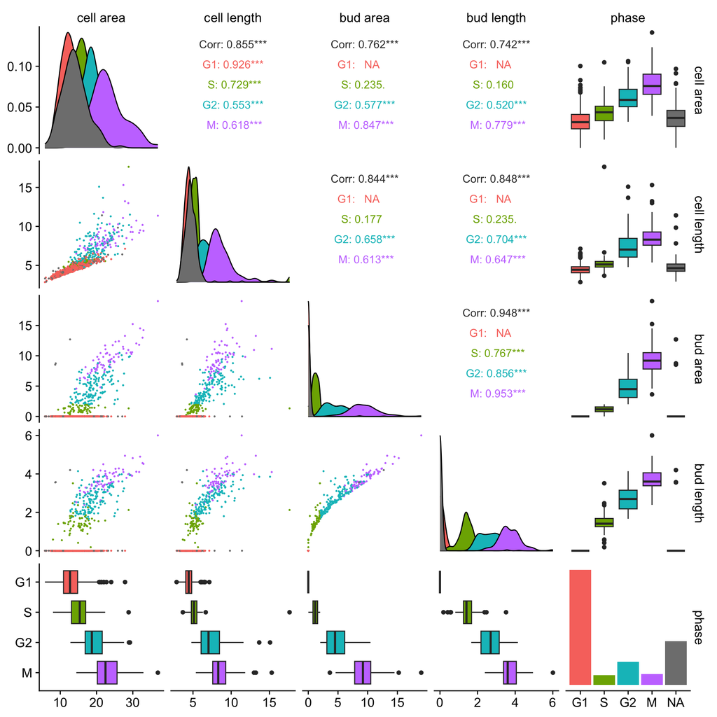

```r
mrna_alldata_wphase %>%
  filter(strain_nice == "mpt5∆", mRNA == "SUN4") %>%
  mutate(axis_major_length_bud_um =
           axis_major_length_bud * pixel_width ) %>%
  select("cell area"   = area_umsq,
         "cell length" = axis_major_length_um,
         "bud area"    = area_bud_umsq,
         "bud length"  = axis_major_length_bud_um,
         "phase"       = cell_cycle_phase) %>%
  ggpairs(aes(colour = phase),
          lower = list(continuous = wrap("points", size = 0.3),
                       combo = wrap("box_no_facet"),
                       discrete = "count") )
```

### Count mRNA by cell cycle phase

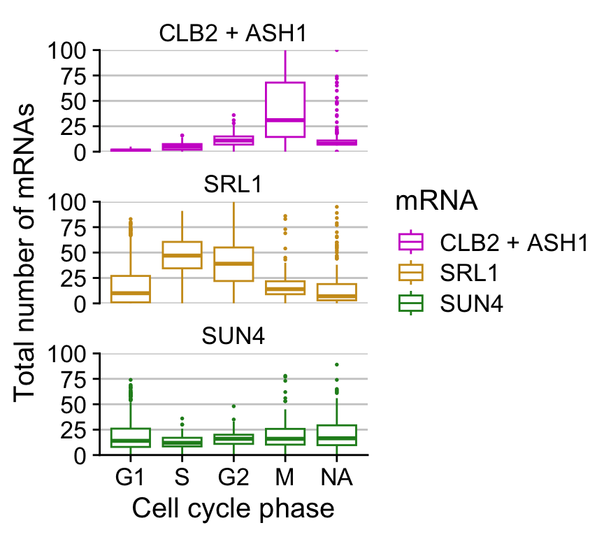

```r
ggplot(data = mrna_alldata_wphase %>%
         filter( strain_nice == "WT")) +
  geom_boxplot(aes(x = cell_cycle_phase, colour = mRNA, y = total_RNAs),
               outlier.size = 0.3) +
  facet_wrap(~ mRNA,
             ncol = 1, scales = "free_y") +
  theme(panel.grid.major.y = element_line(colour = "grey80")) +
  scale_colour_mrna() +
  scale_y_continuous("Total number of mRNAs",
                     limits = c(0,100), expand= c(0,0),
                     oob = scales::squish) +
  labs(y = "Total number of mRNAs",
       x = "Cell cycle phase")
```

```r
ggsave(here::here("figure","countmrna_by_cellcycle_phase_wt.pdf"),
       width = unit(4.5, "in"), height = unit(4, "in") )
```

### localise mRNA by cell cycle phase

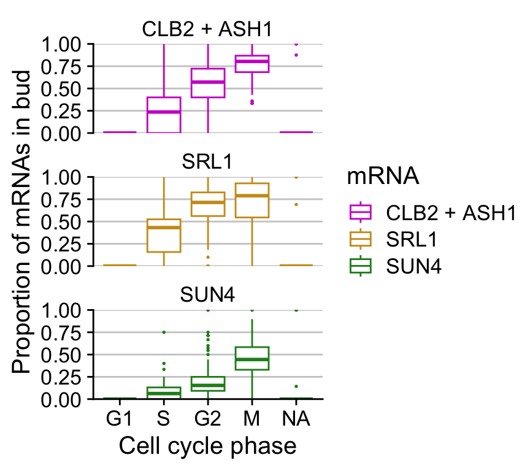

```r
ggplot(data = mrna_alldata_wphase %>%
         filter( strain_nice == "WT")) +
  geom_boxplot(aes(x = cell_cycle_phase, colour = mRNA,
                   y = total_RNAs_bud / total_RNAs),
               outlier.size = 0.3) +
  facet_wrap(~ mRNA,
             ncol = 1, scales = "free_y") +
  theme(panel.grid.major.y = element_line(colour = "grey80")) +
  scale_colour_mrna() +
  scale_y_continuous(limits = c(0,1), expand= c(0,0)) +
  labs(y = "Proportion of mRNAs in bud",
       x = "Cell cycle phase")
```

```r
ggsave(here::here("figure","propmrna_by_cellcycle_phase_wt.pdf"),
       width = unit(4.5, "in"), height = unit(4, "in") )
```

### Count mRNA by cell cycle phase, all strains

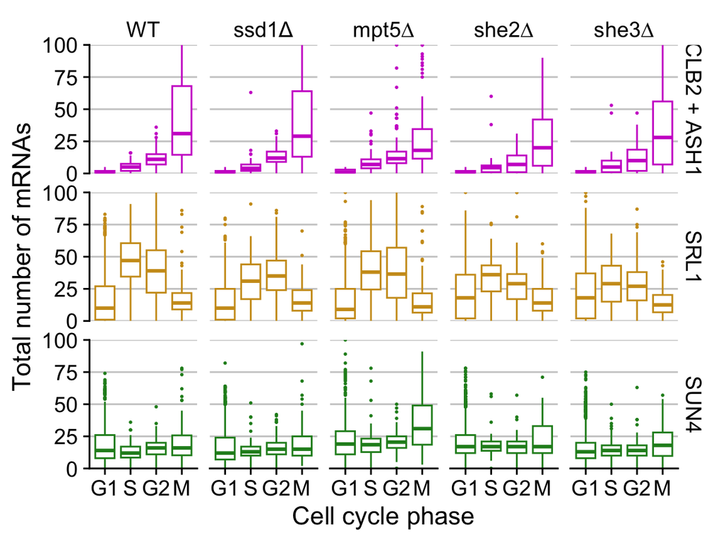

```r
ggplot(data = mrna_alldata_wphase %>%
         filter( strain_nice  %in% c("WT", "ssd1Δ", "mpt5∆", "she2∆", "she3∆"),
                 !is.na(cell_cycle_phase)) ) +
  geom_boxplot(aes(x = cell_cycle_phase, colour = mRNA,
                   y = total_RNAs),
               outlier.size = 0.3) +
  facet_grid(mRNA ~ strain_nice,
             scales = "free_y") +
  theme(panel.grid.major.y = element_line(colour = "grey80")) +
  scale_colour_mrna() +
  scale_y_continuous(limits = c(0,100), expand= c(0,0),
                     oob = scales::squish) +
  labs(y = "Total number of mRNAs",
       x = "Cell cycle phase") +
  theme(legend.position = "none",
        panel.spacing.y = unit(4, "mm"))
```

```r
ggsave(here::here("figure","countmrna_by_cellcycle_phase_allstrains.pdf"),
       width = unit(5.8, "in"), height = unit(4.5, "in"),
       device=cairo_pdf)
```

### Localise mRNA by cell cycle phase, all strains

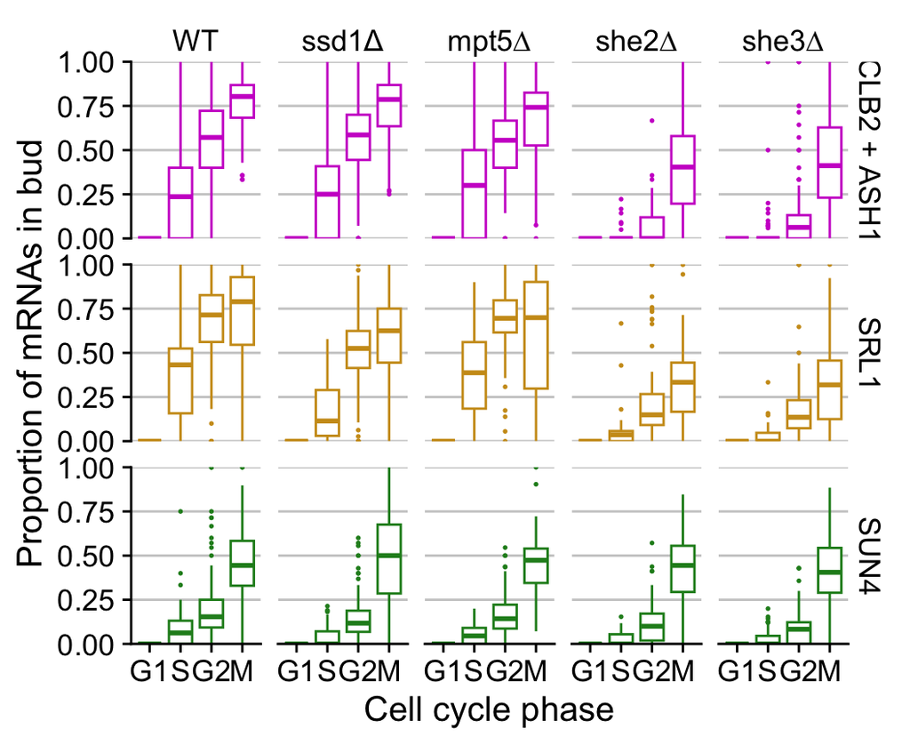

```r
ggplot(data = mrna_alldata_wphase %>%
         filter( strain_nice  %in% c("WT", "ssd1Δ", "mpt5∆", "she2∆", "she3∆"),
                 !is.na(cell_cycle_phase)) ) +
  geom_boxplot(aes(x = cell_cycle_phase, colour = mRNA,
                   y = total_RNAs_bud / total_RNAs),
               outlier.size = 0.3) +
  facet_grid(mRNA ~ strain_nice,
             scales = "free_y") +
  theme(panel.grid.major.y = element_line(colour = "grey80")) +
  scale_colour_mrna() +
  scale_y_continuous(limits = c(0,1), expand= c(0,0)) +
  labs(y = "Proportion of mRNAs in bud",
       x = "Cell cycle phase") +
  theme(legend.position = "none",
        panel.spacing.y = unit(4, "mm"))
```

```r
ggsave(here::here("figure","propmrna_by_cellcycle_phase_allstrains.pdf"),
       width = unit(5.8, "in"), height = unit(4.5, "in"),
       device=cairo_pdf)
```

# Output samples of cells by strain and cell cycle phase

Goal here is to ample at random a small number of cells from each subset that we want to highlight, so that we can spot-check the statistics against cell images and also choose cells to display in a mostly unbiased way.

```r
sample_cells_byphase <- function(df, mystrain, myphase, n = 10) {
  df %>%
    filter(mRNA == "CLB2 + ASH1", # because cell stats are repeated 3x
           strain_nice == mystrain,
           cell_cycle_phase == myphase) %>%
    slice_sample(n=n) %>%
    arrange(row_id)
}

write_sample_cells_byphase <-
  function(df, mystrain, myphase, filename, n = 10, dirstem = "output") {
    sample_cells_byphase(df = df, mystrain = mystrain, myphase = myphase, n=n) %>%
      select(row_id, uid, strain, condition, replicate, fov, image_cell_id, source_folder) %>%
      write_csv(file = here::here(dirstem, filename))
  }

# test it.
mrna_alldata_wphase %>%
  sample_cells_byphase("WT","G1")
```

```
## # A tibble: 10 × 57
##    row_id image_cell_id bbox_0 bbox_1 bbox_2 bbox_3  area eccentricity
##     <dbl>         <dbl>  <dbl>  <dbl>  <dbl>  <dbl> <dbl>        <dbl>
##  1   4963            56   1357    672   1414    738  2899        0.650
##  2   5175            94   1515    196   1572    253  2434        0.414
##  3   5427            90   1498    706   1573    766  3429        0.606
##  4  24731           302   2095    817   2156    871  2506        0.640
##  5  25132            98   1623   1237   1680   1291  2391        0.358
##  6  27964           226   1370    807   1425    881  3098        0.734
##  7  32422            13    298    652    380    717  4149        0.608
##  8  32457            55   1679    479   1755    556  4171        0.721
##  9  33643           144   2142    187   2198    245  2548        0.326
## 10  34429            71   1071   1939   1140   2001  3338        0.540
## # ℹ 49 more variables: axis_minor_length <dbl>, axis_major_length <dbl>,
## #   orientation <dbl>, perimeter <dbl>, solidity <dbl>, bbox_0_bud <dbl>,
## #   bbox_1_bud <dbl>, bbox_2_bud <dbl>, bbox_3_bud <dbl>, area_bud <dbl>,
## #   eccentricity_bud <dbl>, axis_minor_length_bud <dbl>,
## #   axis_major_length_bud <dbl>, orientation_bud <dbl>, perimeter_bud <dbl>,
## #   solidity_bud <dbl>, spots <dbl>, dense_regions <dbl>,
## #   decomposed_RNAs <dbl>, tx <dbl>, nascent_RNAs <dbl>, total_RNAs <dbl>, …
```

Spot-check non-assigned cells, in file `NA_sample20cells.csv`.

```r
# Spot-check non-assigned cells
set.seed(2026) # set seed so same pseudorandom sample each time
mrna_alldata_wphase %>%
  filter(mRNA == "CLB2 + ASH1", # because cell stats are repeated 3x
         # strain_nice == "WT",
         is.na(cell_cycle_phase)) %>%
  slice_sample(n=20) %>%
  arrange(row_id)%>%
  select(row_id, uid, strain, condition, replicate, fov, image_cell_id, source_folder) %>%
  write_csv(file = here::here("output", "NA_sample20cells.csv"))

# write_sample_cells_byphase(mrna_alldata_wphase,
#                            "WT",
#                            "G1",
#                            "WT_G1_sample16cells.csv"
#                           )
```

The next chunk gives ids for 20 cells sampled at random for each combination of

- strain (WT, ssd1∆, mpt5∆, she2∆, she3∆)
- cell cycle phase (G1, S, G2, M)

For example, file `WT_G1_sample20cells.csv` has 20 cells from WT in G1.

```r
set.seed(2026)
expand_grid(strain_nice  = c("WT", "ssd1Δ", "mpt5∆", "she2∆", "she3∆"),
            cell_cycle_phase = c("G1", "S", "G2", "M")) %>%
  rowwise() %>%
  do(write_sample_cells_byphase(df = mrna_alldata_wphase,
                                mystrain = .$strain_nice,
                                myphase = .$cell_cycle_phase,
                                filename = paste(.$strain_nice,
                                                 .$cell_cycle_phase,
                                                 "sample20cells.csv",
                                                 sep = "_"),
                                n = 20)
     )
```

```
## # A tibble: 400 × 8
## # Rowwise:
##    row_id uid       strain condition replicate fov   image_cell_id source_folder
##     <dbl> <chr>     <chr>  <chr>     <fct>     <chr>         <dbl> <chr>
##  1   5158 YET915_B… YET915 WT        BR5       01               74 ../../240909…
##  2   5658 YET915_B… YET915 WT        BR5       03                8 ../../240909…
##  3  24927 YET915_B… YET915 WT        BR3       01               36 ../../220601…
##  4  24932 YET915_B… YET915 WT        BR3       01               41 ../../220601…
##  5  24937 YET915_B… YET915 WT        BR3       01               48 ../../220601…
##  6  25074 YET915_B… YET915 WT        BR3       03               26 ../../220601…
##  7  25137 YET915_B… YET915 WT        BR3       03              103 ../../220601…
##  8  25146 YET915_B… YET915 WT        BR3       03              113 ../../220601…
##  9  25401 YET915_B… YET915 WT        BR3       04               61 ../../220601…
## 10  25422 YET915_B… YET915 WT        BR3       04               85 ../../220601…
## # ℹ 390 more rows
```